# Numpy+Pandas作業五

## 程式作業五

### 第一題：

**請限定利用 Pandas 套件來讀取 data1.csv 內的資料，並將讀取出來的資料轉換成 DataFrame 型態，再完成以下要求：**

1. **改變索引值為從 1 開始而非從 0 開始，並顯示其結果(請參考如何使用 Pandas 中的 set_index())**
2. **顯示前兩筆紀錄的資料(請參考如何使用 Pandas 中的 head())**
3. **挑選並顯示〝白醋〞這個品項的進貨紀錄(請在網路上參考如何使用 Pandas 的指定欄位與欄位名稱方法)**
4. **計算表格中各種不同單位的商品數量並顯示於螢幕上(請參考如何使用 Pandas 中的 groupby() 與其相關的屬性與方法)**
5. **根據進貨日期從小到大排序並輸出結果，但資料的索引值無須變更重設(請參考如何使用 Pandas 中 sort_values())**  
   **本題執行的結果預期如下圖中所示：**

[figure not shown]

#### ※ 以上每一個子題限定使用 NumPy, Pandas, Matplotlib 提供的方法完成；切記：每題答案如果超過二行指令就是錯的！

```python
import numpy as np     # 讀入 Numpy 函式庫
import pandas as pd    # 讀入 Pandas 函式庫
```

### 根據題目所給的資料檔案，建立一個 Pandas 的 DataFrame 資料結構

```python
df = pd.read_csv("data1.csv", encoding = "utf8")  # 匯入csv檔，並編碼UTF-8

print(df, '\n')    # 印出全部 DataFrame 內的資料
```

```
  商品名稱       進貨日期  數量  單位
0   鹽巴   2019/5/2  15  公升
1   白醋   2019/5/2  10  公升
2   醬油   2019/5/9  15  公升
3  胡椒粉  2019/5/10  12   包
4  辣椒粉  2019/4/30   8   包
```

### 1. 改變索引值為從 1 開始而非從 0 開始，並顯示其結果

```python
df2 = df.set_index(pd.Index([1, 2, 3, 4,5]))   # 把index改成1~5
#  df2 = df.set_index(np.arange(1, len(df)+1))
print(df2)    # 印出結果
```

```
  商品名稱       進貨日期  數量  單位
1   鹽巴   2019/5/2  15  公升
2   白醋   2019/5/2  10  公升
3   醬油   2019/5/9  15  公升
4  胡椒粉  2019/5/10  12   包
5  辣椒粉  2019/4/30   8   包
```

### 2. 顯示前兩筆紀錄的資料

```python
print(df2.head(2), '\n')  # 取得前 2 筆
```

```
  商品名稱      進貨日期  數量  單位
1   鹽巴  2019/5/2  15  公升
2   白醋  2019/5/2  10  公升
```

### 3. 挑選並顯示〝白醋〞這個品項的進貨紀錄

```python
print(df2.iloc[[1]])  # 取得df2 index1的位置
#  df2[df2["商品名稱"] == '白醋']
```

```
  商品名稱      進貨日期  數量  單位
2   白醋  2019/5/2  10  公升
```

### 4. 計算表格中各種不同單位的商品數量並顯示於螢幕上

```python
print(df2.groupby("單位").size())  # 針對單位算出個別個數

df2.groupby("單位")["商品名稱"].count()
```

```
單位
公升    3
包     2
dtype: int64
```

```
單位
公升    3
包     2
Name: 商品名稱, dtype: int64
```

```python
print(df2.sort_values(by=["進貨日期"]))  # 根據進貨日期由小到大排序
```

```
  商品名稱       進貨日期  數量  單位
5  辣椒粉  2019/4/30   8   包
4  胡椒粉  2019/5/10  12   包
1   鹽巴   2019/5/2  15  公升
2   白醋   2019/5/2  10  公升
3   醬油   2019/5/9  15  公升
```

### 第二題：

**建立一個學生資料名單如下，並請完成以下的需求：

> Name = [‘張甲’, ’王大同’, ’倪再興’, ’余筱雯’, ’李琳一’, ’邊方’]

[figure not shown]

#### ※ 以上每一個子題限定使用 NumPy, Pandas, Matplotlib 提供的方法完成；切記：每題答案如果超過二行指令就是錯的！

```python
import numpy as np     # 讀入 Numpy 函式庫
import pandas as pd    # 讀入 Pandas 函式庫
```

### 根據題目所給的資料內容，建立一個 Pandas 的 DataFrame 資料結構

**(本子題限四行指令內完成)**

```python
df = pd.DataFrame({"Name" : ['張甲', '王大同', '倪再興', '余筱雯', '李琳一', '邊方'],

                   "Score" : [65, 98, 82, 77, 61, 92]})  # 建立dataframe
print(df)  # 印出結果
```

```
  Name  Score
0   張甲     65
1  王大同     98
2  倪再興     82
3  余筱雯     77
4  李琳一     61
5   邊方     92
```

### 1. 將學生資料轉成 DataFrame 的結構之後，請改變其索引值為為從 1 開始並列印出 DataFrame 內的資料

```python
df2 = df.set_index(pd.Index([1, 2, 3, 4,5,6]))  # 重新設置index 1~5
print(df2)  # 印出結果
```

```
  Name  Score
1   張甲     65
2  王大同     98
3  倪再興     82
4  余筱雯     77
5  李琳一     61
6   邊方     92
```

### 2. 請列出資料根據名字從小到大排序之後的結果，但資料的索引值無須變更重設

```python
print(df2.sort_values(by=["Name"]))  # 根據名字從小到大排序
```

```
  Name  Score
4  余筱雯     77
3  倪再興     82
1   張甲     65
5  李琳一     61
2  王大同     98
6   邊方     92
```

### 3. 請列出資料根據分數從大到小排序之後的結果，但資料的索引值無需變更重設

```python
df3 = df2.sort_values(by=["Score"], ascending = False)   # 根據分數從大到小排序
print(df3)   # 印出結果
```

```
  Name  Score
2  王大同     98
6   邊方     92
3  倪再興     82
4  余筱雯     77
1   張甲     65
5  李琳一     61
```

### 4. 請列出分數高於 80 分的學生其所有相關資料

```python
print(df3[df3["Score"] > 80])   # 列出分數>80的學生
```

```
  Name  Score
2  王大同     98
6   邊方     92
3  倪再興     82
```

### 第三題：

**兩家公司(A公司與B公司)的五個部門(人事部門、會計部門、設計部門、行銷部門、採購部門)員工數量分別為 A：8、5、10、12、5，以及 B：10、8、20、18、12。請使用 Matplotlib 視覺化工具繪出兩個圓餅圖描述上述資料，圖表設定樣式需求如下：**

1. **圖上所有標籤文字一律要使用英文(免得中文字會顯示不出來)**
2. **各部門在圖上請以英文名稱來呈現，依序對應為Personnel Department, Accounting Department, Design Department, Marketing Department, Purchasing Department**
3. **各部門所使用的區塊顏色依序對應為：violet, yellow, skyblue, lightcoral, lightgreen**
4. **圓餅圖上請突顯”行銷部門”**
5. **數據顯示格式：小數點後一位**
6. **起始角度：90**
7. **圖表形狀：圓形，而非橢圓形**
8. **圖1名稱：Company A**
9. **圖2名稱：Company B**
10. **圖表名稱字型大小：20pts**

**完成本題所需要使用到的技巧除了參考老師的教材以外，務必請參閱(看完再寫)：** [[1]](https://ithelp.ithome.com.tw/articles/10196410), [[2]](https://www.w3schools.com/python/matplotlib_pie_charts.asp), [[3]](https://www.tutorialspoint.com/matplotlib/matplotlib_pie_chart.htm), [[4]](https://statistics-using-python.blogspot.com/2019/09/python-pie-chart-using-python.html), [[5]](https://zi.media/@newaurorapixnetnetblog/post/DsZGsH)

**本題執行的結果預期如下圖中所示：**

[figure not shown]

#### ※ 以上每一個子題限定使用 NumPy, Pandas, Matplotlib 提供的方法完成；本題指令不限行數！

```python
import matplotlib.pyplot as plt    # 讀入 Matplotlib 中的 pyplot 函式庫
import numpy as np     # 讀入 Numpy 函式庫
import pandas as pd    # 讀入 Pandas 函式庫
```

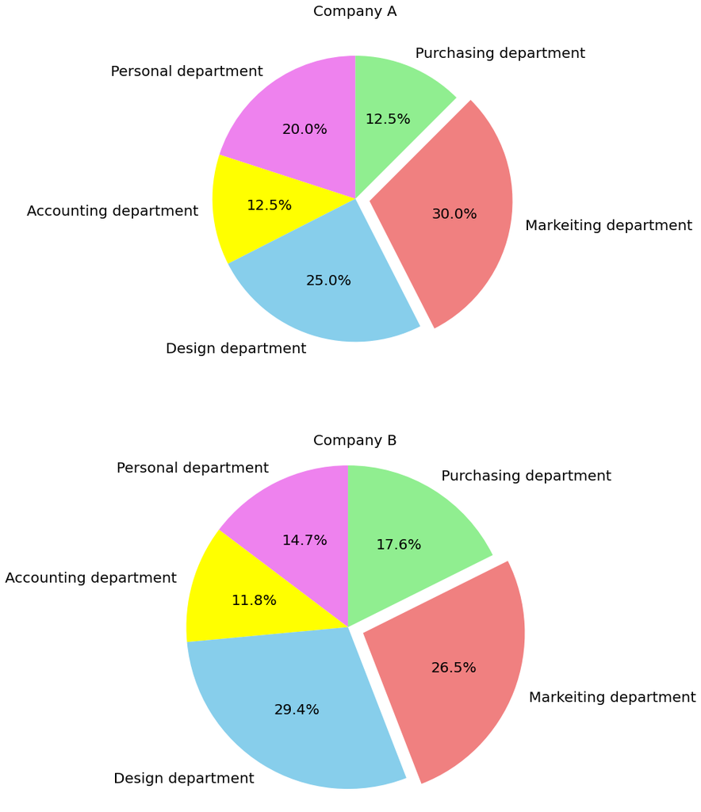

```python
#======= 作圖設定 ========#
plt.figure(figsize=(10,20))   # 設定圖形大小
labels = ["Personal department","Accounting department",  "Design department"
          ,"Markeiting department","Purchasing department"]   # 指定部門
ratings_A = [8, 5, 10, 12, 5]   # A公司人數
ratings_B = [10, 8, 20, 18, 12]  # B公司人數
colors = ['violet', 'yellow', 'skyblue','lightcoral','lightgreen']  # 圖形顏色
explode = (0, 0, 0, 0.1, 0)  # 將 行銷部門 突出

#======= 開始繪圖 ========#
plt.subplot(2, 1, 1)  # 畫 A公司的圖
plt.title("Company A",fontsize = 20)   # 設定標題名稱及大小
plt.pie(ratings_A, labels = labels,colors=colors,explode=explode,
        autopct='%1.1f%%' ,textprops = {"fontsize" : 20},startangle=90) # 畫圓餅圖

plt.subplot(2, 1, 2)  # 畫 B公司的圖
plt.title("Company B",fontsize = 20)   # 設定標題名稱及大小
plt.pie(ratings_B, labels = labels,colors=colors ,explode=explode,
        autopct='%1.1f%%',textprops = {"fontsize" : 20},startangle=90)  # 畫圓餅圖

plt.axis("equal")  # 設定圓餅圖長寬等長
plt.show()  # 作圖結果
```